# Структура научной презентации

Простейший вариант

Mehmet Efe Kantoz

1032228428@pfur.ru

Российский университет дружбы народов

30.08.2026

# Информация

## Докладчик

- Mehmet Efe Kantoz
- Ctudent 3 kypc
- Российский университет дружбы народов им. П. Лумумбы
- 1032228428@pfur.ru

# Цель работы

# Задание

- Создать рабочий каталог для кода.
- Установить необходимые пакеты.
- Выполнить предложенный код.
- Преобразовать код в литературный стиль.
- Сгенерировать из литературного кода:
- чистый код;
- jupyter notebook;
- документацию в формате Quarto.
- Выполнить код из jupyter notebook.
- Интегрировать документацию в формате Quarto в отчёт.
- Добавить в код в литературном стиле вычисление для набора параметров.
- Сгенерировать из литературного кода с параметрами:
- чистый код;
- jupyter notebook;
- документацию в формате Quarto.
- Выполнить код из jupyter notebook с параметрами.
- Интегрировать документацию с параметрами в формате Quarto в отчёт.

## Ограничения классического подхода

Несмотря на широкое применение, модель на ОДУ имеет ряд ограничений:

- Однородность популяции — все индивиды считаются одинаковыми.
- Отсутствие пространственной структуры — предполагается полное перемешивание.
- Детерминированность — не учитываются случайные флуктуации.
- Непрерывность — количество людей рассматривается как непрерывная величина.

## Динамика

На каждом шаге (соответствует одному дню) для каждого агента выполняются следующие процессы :

- Миграция — агент может переместиться в другую локацию с вероятностью, заданной матрицей migration_rates.
- Передача инфекции — если агент инфицирован, он может заразить восприимчивых агентов в той же локации. Количество заражённых за день определяется пуассоновским процессом с интенсивностью, зависящей от статуса выявления (β_und или β_det).
- Обновление счётчика — для инфицированных увеличивается days_infected.
- Выздоровление или смерть — если days_infected достиг infection_period, агент либо выздоравливает (переходит в R), либо умирает (удаляется из модели) с вероятностью death_rate. Выздоровевшие могут быть повторно инфицированы с вероятностью reinfection_probability.

## Выполнение лабораторной работы

## Код модели

Создаю скрипт модели, который будет использоваться как основа для дальнейшей работы (рис. 1).

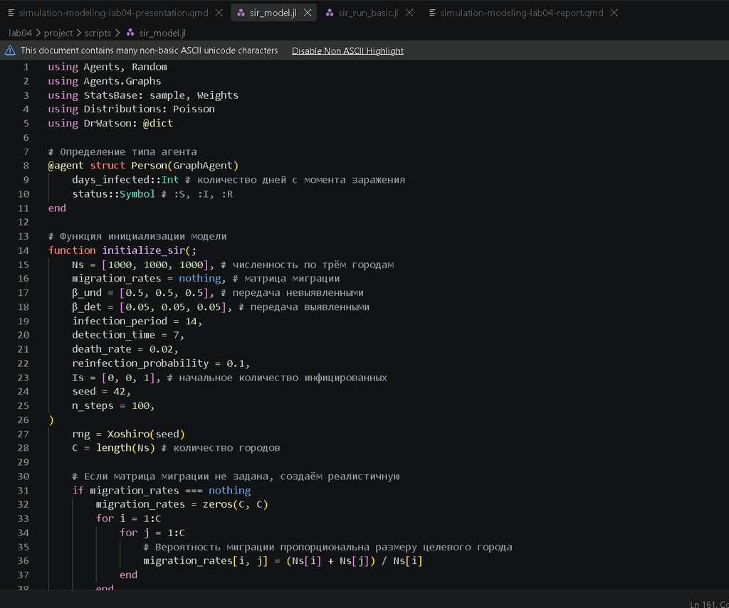

Рисунок 1: sir_model

## Базовый эксперимент

[figure not shown]

Рисунок 2: sir_run_basic

## Базовый эксперимент

Создаю все производные форматы(рис. 3).

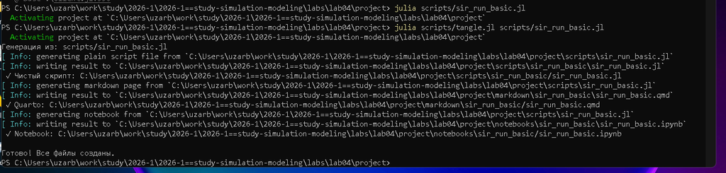

Рисунок 3: производные форматы

## Базовый эксперимент

Запускаю jupyter notebook(рис. 4).

[figure not shown]

Рисунок 4: notebook

## Базовый эксперимент

Получаем следующий график(рис. 5).

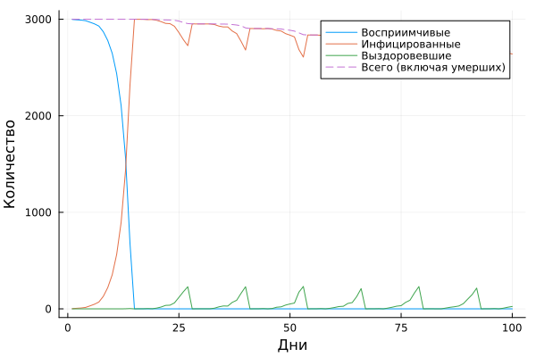

Рисунок 5: notebook

## Сканирование коэффициента заразности

Создаю скрипт, который исследует, как изменение базовой заразности влияет на эпидемические показатели(рис. 6).

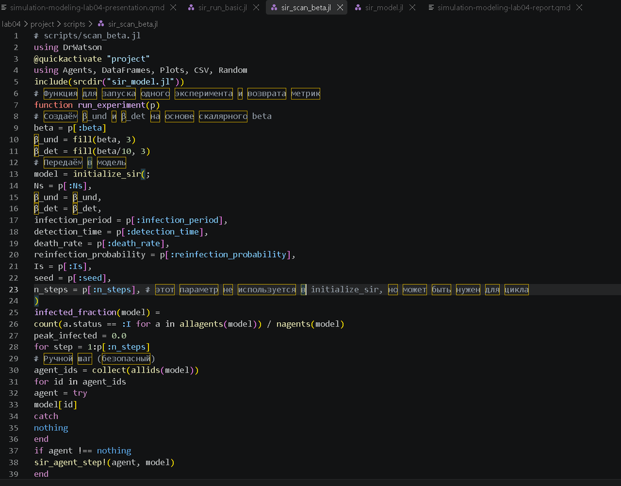

Рисунок 6: sir_scan_beta

## Сканирование коэффициента заразности

Запускаю данный скрипт(рис. 7).

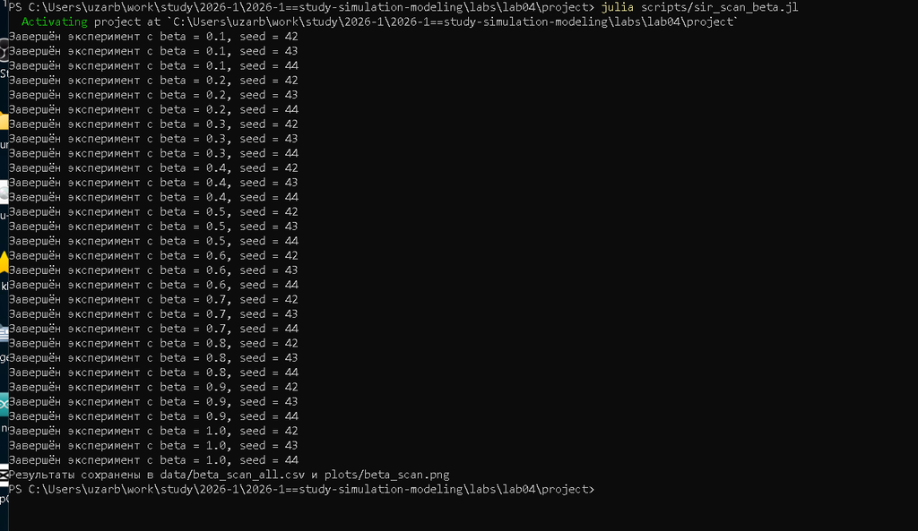

Рисунок 7: Запуск

## Сканирование коэффициента заразности

Проверяю создание .csv файла с результатами(рис. 8).

[figure not shown]

Рисунок 8: csv

## Сканирование коэффициента заразности

Создаю производные файлы(рис. 9).

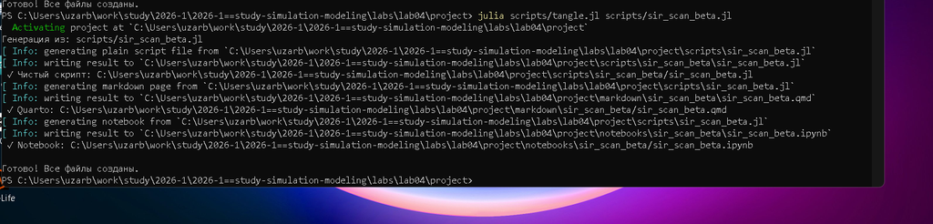

Рисунок 9: notebook

## Сканирование коэффициента заразности

Запускаю ноутбук(рис. 10).

[figure not shown]

Рисунок 10: notebook

## Сканирование коэффициента заразности

После запуска сприпта получился следующий график(рис. 11).

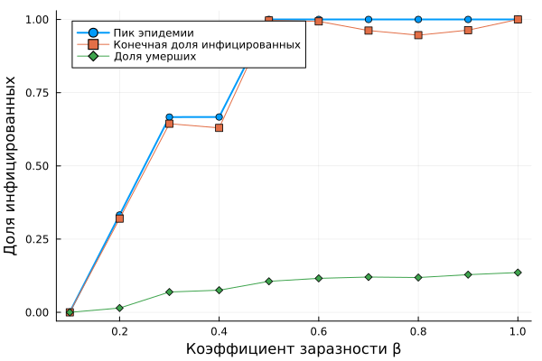

Рисунок 11: beta_scan.png

## Исследование эффекта миграции

Создаю скрипт, который исследует, как эффективность перемещения людей между городами влияет на скорость распространения эпидемии и масштаб пика(рис. 12).

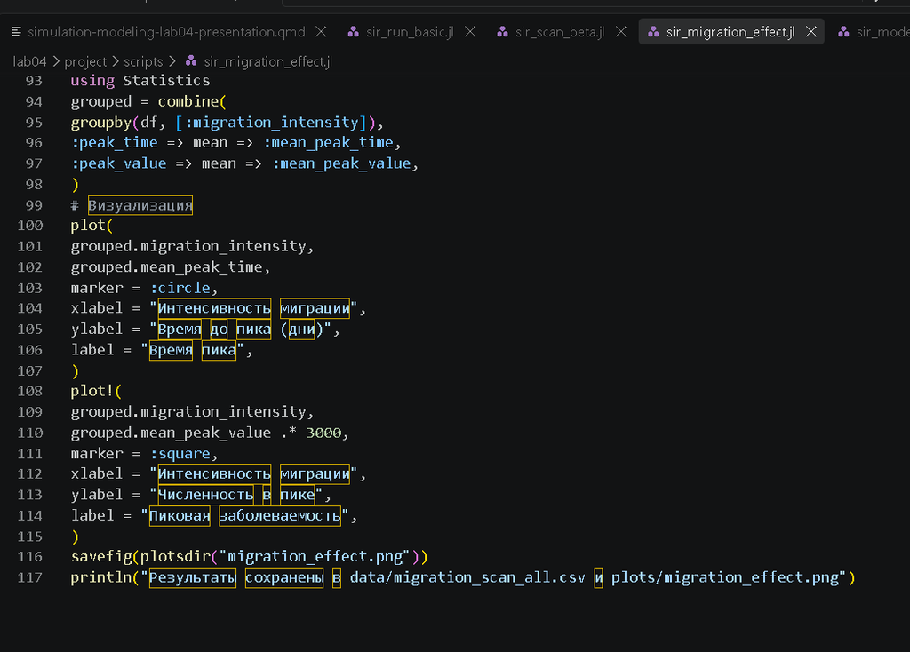

Рисунок 12: миграция

## Исследование эффекта миграции

Запускаю данный скрипт(рис. 13).

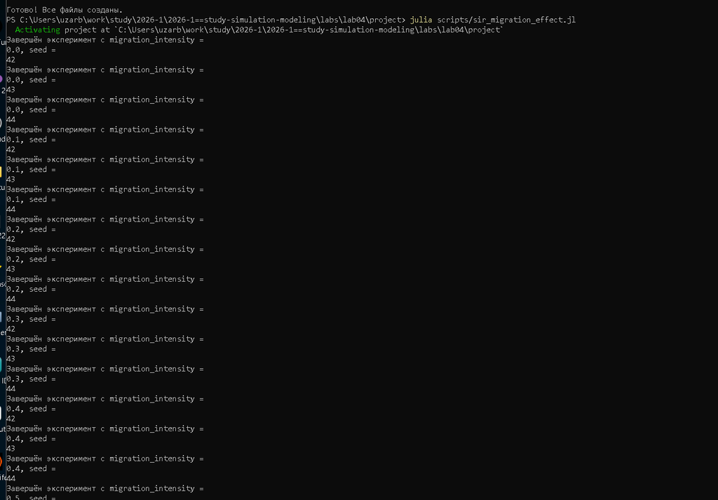

Рисунок 13: запуск

## Исследование эффекта миграции

Проверяю наличия файла csv с результатами скрипта(рис. 14).

[figure not shown]

Рисунок 14: csv

## Исследование эффекта миграции

Создаю все производные форматы(рис. 15).

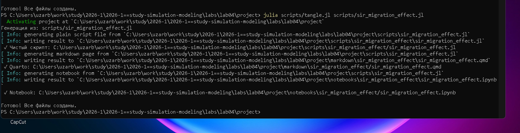

Рисунок 15: notebook

## Исследование эффекта миграции

Запускаю файл ноутбук(рис. 16).

[figure not shown]

Рисунок 16: notebook

## Исследование эффекта миграции

Получаю следующий график(рис. 17).

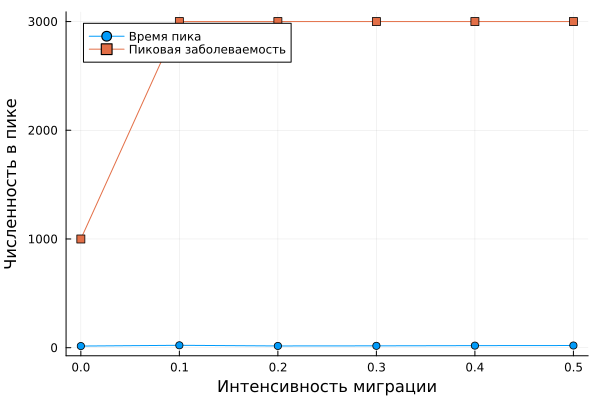

Рисунок 17: migration_effect.png

## Многокритериальная опитимизация параметров

Создаю и запускаю скрипт, который ищет оптимальные комбинации параметров, минимизирующие одновременно два критерия: пиковую заболеваемоть и долю умерших(рис. 18).

[figure not shown]

Рисунок 18: опитимизация

## Многокритериальная опитимизация параметров

Создаю все производные форматы(рис. 19).

[figure not shown]

Рисунок 19: notebook

## Многокритериальная опитимизация параметров

Запускаю ноутбук(рис. 20).

[figure not shown]

Рисунок 20: notebook

## Сводная визуализация результатов

Создаю и запускаю скрипт, который загружает результаты параметрического сканирования и строит единый составной график, объединяющий три панели(рис. 21).

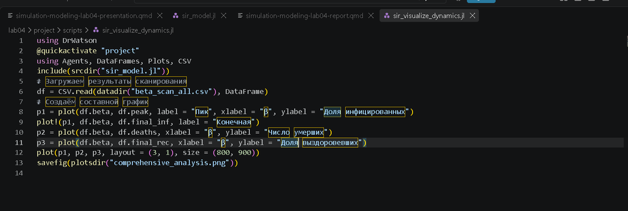

Рисунок 21: визуализация

## Сводная визуализация результатов

Создаю все производные форматы(рис. 22).

[figure not shown]

Рисунок 22: notebook

## Сводная визуализация результатов

Запускаю ноутбук (рис. 23).

[figure not shown]

Рисунок 23: notebook

## Сводная визуализация результатов

В результате получаю следующий график(рис. 24).

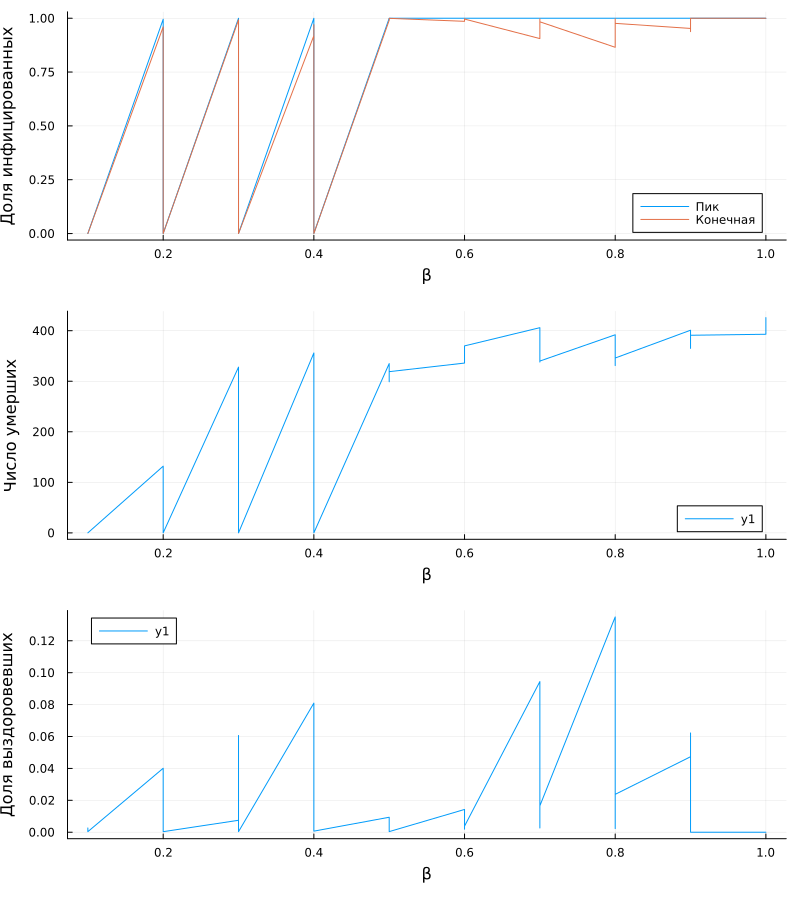

Рисунок 24: comprehensive_analysis.png

## Выводы

После выполнения данной лабораторной работы мы создали эпидемическую модель sir через агентный подход